# Homework ASM (SoSe 2021) – Week 8

Marc Blauert

2021-06-02

### Tasks: McElreath Ch. 8.5, Ex. 8H1/8H2

#### Task 1: Ex. 8H1:

Return to the data(tulips) example in the chapter (8). Now include the bed variable as a predictor in the interaction model. Don’t interact bed with the other predictors; just include it as a main effect. Note that bed is categorical. So to use it properly, you will need to either construct dummy variables or rather an index variable, as explained in Chapter 5.

##### Load data

```r
data(tulips, package = "rethinking")
d <- tulips

rm(tulips)
```

##### Wrangle with data

```r
d <-
  d %>%
  mutate(blooms_std = blooms / max(blooms),
         water_cent = water - mean(water),
         shade_cent = shade - mean(shade),
         bed = factor(bed))

levels(d$bed) <- c("A", "B", "C")

str(d)
```

```
## 'data.frame':    27 obs. of  7 variables:
##  $ bed       : Factor w/ 3 levels "A","B","C": 1 1 1 1 1 1 1 1 1 2 ...
##  $ water     : int  1 1 1 2 2 2 3 3 3 1 ...
##  $ shade     : int  1 2 3 1 2 3 1 2 3 1 ...
##  $ blooms    : num  0 0 111 183.5 59.2 ...
##  $ blooms_std: num  0 0 0.307 0.507 0.164 ...
##  $ water_cent: num  -1 -1 -1 0 0 0 1 1 1 -1 ...
##  $ shade_cent: num  -1 0 1 -1 0 1 -1 0 1 -1 ...
```

##### Estimate the interaction model from Chapter 8 with the addtional categorical variable `bed`

Model equation:

$$\begin{align*}
\text{blooms_std}_i & \sim \operatorname{Normal}(\mu_i, \sigma) \\
\mu_i & = \alpha + \beta_1 \text{water_cent}_i + \beta_2 \text{shade_cent}_i + \beta_3 \text{shade_cent}_i \cdot \text{water_cent}_i + \beta_4 \text{bed}_i\\
\alpha & \sim \operatorname{Normal}(0.5, 0.25) \\
\beta_1 & \sim \operatorname{Normal}(0, 0.25) \\
\beta_2 & \sim \operatorname{Normal}(0, 0.25) \\
\beta_3 & \sim \operatorname{Normal}(0, 0.25) \\
\beta_4 & \sim \operatorname{Normal}(0, 0.25) \\
\sigma & \sim \operatorname{Exponential}(1) \\
\end{align*}$$

```r
b8.5_bed <-
  brm(data = d,
      family = gaussian,
      blooms_std ~ 1 + water_cent + shade_cent + water_cent:shade_cent + bed,
      prior = c(prior(normal(0.5, 0.25), class = Intercept),
                prior(normal(0, 0.25), class = b),
                prior(exponential(1), class = sigma)),
      iter = 2000, warmup = 1000, chains = 4, cores = 4,
      seed = 8,
      file = "fits/b08.05_bed")

#plot(b8.5_bed)

print(b8.5_bed)
```

```
##  Family: gaussian
##   Links: mu = identity; sigma = identity
## Formula: blooms_std ~ 1 + water_cent + shade_cent + water_cent:shade_cent + bed
##    Data: d (Number of observations: 27)
## Samples: 4 chains, each with iter = 2000; warmup = 1000; thin = 1;
##          total post-warmup samples = 4000
##
## Population-Level Effects:
##                       Estimate Est.Error l-95% CI u-95% CI Rhat Bulk_ESS
## Intercept                 0.28      0.04     0.19     0.36 1.00     4266
## water_cent                0.21      0.03     0.14     0.27 1.00     5712
## shade_cent               -0.11      0.03    -0.18    -0.05 1.00     5954
## bedB                      0.12      0.06    -0.01     0.24 1.00     4245
## bedC                      0.13      0.06     0.00     0.25 1.00     4506
## water_cent:shade_cent    -0.14      0.04    -0.22    -0.07 1.00     5597
##                       Tail_ESS
## Intercept                 2680
## water_cent                2914
## shade_cent                2869
## bedB                      2835
## bedC                      2952
## water_cent:shade_cent     3110
##
## Family Specific Parameters:
##       Estimate Est.Error l-95% CI u-95% CI Rhat Bulk_ESS Tail_ESS
## sigma     0.13      0.02     0.10     0.18 1.00     3653     2757
##
## Samples were drawn using sampling(NUTS). For each parameter, Bulk_ESS
## and Tail_ESS are effective sample size measures, and Rhat is the potential
## scale reduction factor on split chains (at convergence, Rhat = 1).
```

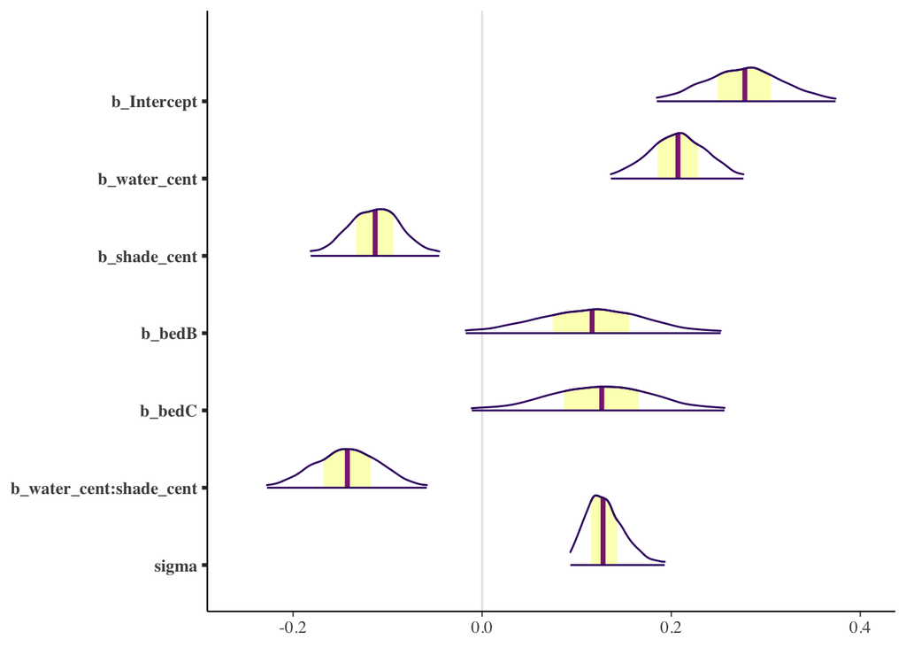

```r
color_scheme_set("viridisA")
mcmc_plot(b8.5_bed, type = "areas", prob = 0.5, prob_outer = 0.97)
```

##### Interpretation of model results for `bed` categories

From the model results and the corresponding coefficient plot, it appears that beds B and C have a higher proportion of flowers than the reference category, bed A, when water and shade conditions and their interaction are considered. This may indicate that other growing conditions beyond water and shade, which are not accounted for in the model, are systematically better in beds B and C than in bed A. Such growing conditions may be soil composition or temperature.

#### Task 2: Ex. 8H2:

Use WAIC to compare the model from 8H1 to a model that omits bed. What do you infer from this comparison? Can you reconcile the WAIC results with the posterior distribution of the bed coefficients?

##### Re-estimate the interaction model (this time NO additional categorical `bed` variable)

```r
b8.5 <-
  brm(data = d,
      family = gaussian,
      blooms_std ~ 1 + water_cent + shade_cent + water_cent:shade_cent,
      prior = c(prior(normal(0.5, 0.25), class = Intercept),
                prior(normal(0, 0.25), class = b),
                prior(exponential(1), class = sigma)),
      iter = 2000, warmup = 1000, chains = 4, cores = 4,
      seed = 8,
      file = "fits/b08.05")

print(b8.5)
```

```
##  Family: gaussian
##   Links: mu = identity; sigma = identity
## Formula: blooms_std ~ 1 + water_cent + shade_cent + water_cent:shade_cent
##    Data: d (Number of observations: 27)
## Samples: 4 chains, each with iter = 2000; warmup = 1000; thin = 1;
##          total post-warmup samples = 4000
##
## Population-Level Effects:
##                       Estimate Est.Error l-95% CI u-95% CI Rhat Bulk_ESS
## Intercept                 0.36      0.03     0.30     0.41 1.00     4637
## water_cent                0.21      0.03     0.14     0.27 1.00     5153
## shade_cent               -0.11      0.03    -0.18    -0.05 1.00     4590
## water_cent:shade_cent    -0.14      0.04    -0.22    -0.06 1.00     4445
##                       Tail_ESS
## Intercept                 2477
## water_cent                2898
## shade_cent                3183
## water_cent:shade_cent     2519
##
## Family Specific Parameters:
##       Estimate Est.Error l-95% CI u-95% CI Rhat Bulk_ESS Tail_ESS
## sigma     0.14      0.02     0.11     0.20 1.00     2926     3290
##
## Samples were drawn using sampling(NUTS). For each parameter, Bulk_ESS
## and Tail_ESS are effective sample size measures, and Rhat is the potential
## scale reduction factor on split chains (at convergence, Rhat = 1).
```

##### Model comparison

```r
b8.5 <- add_criterion(b8.5, c("loo", "waic"))
b8.5_bed <- add_criterion(b8.5_bed, c("loo", "waic"))

loo_compare(b8.5, b8.5_bed, criterion = "waic") %>% print(simplify = F)
```

```
##          elpd_diff se_diff elpd_waic se_elpd_waic p_waic se_p_waic waic
## b8.5_bed   0.0       0.0    13.9       3.3          6.0    1.3     -27.7
## b8.5      -1.5       2.5    12.4       3.8          4.4    1.1     -24.8
##          se_waic
## b8.5_bed   6.5
## b8.5       7.5
```

```r
model_weights(b8.5, b8.5_bed, weights = "waic") %>% round(digits = 3)
```

```
##     b8.5 b8.5_bed
##    0.189    0.811
```

The `loo_compare` and the `model_weights` functions used with the `waic` criterion indicate that the model which includes the categorical `bed` variable performs slightly better than the one without. Yet, the `elpd_diff` is lower than the `se_diff` which leads to an ambiguous outcome for this comparison of model fit.

What surprises me is that the difference between reference bed A and the other two beds (B and C) seems to be quite strong (see the coefficient plot above), but the model performs only slightly better. Intuitively, I would have expected a stronger difference in model fit in favor of `b8.5_bed`. Is it perhaps because many of the posterior distributions (all except `shade_cent`and the interaction term) cluster in the same area?